# Project 2: Dimension Reduction

Yimo Shen

02/23/2022

### Part 1

#### PCA Function

```r
# function: my_pca, runs PCA on a data matrix
# input:
#   X: a matrix (or dataframe) to perform PCA on
#   scale: a logical value, if TRUE then run PCA on the centered and scaled version of X
#     if FALSE then run PCA on the centered but non-scaled version of X
# output:
#   prin_comps: a matrix That contains the principal component vectors
#   loadings: a matrix of variable loadings
#   portion_var:  a vector of variances explained by each principal component
my_pca <- function(X, scale) {
  # Mean center each variable of data matrix X to get X*
  x_centered <- scale(X, scale = FALSE)
  if (scale) {
    # Scale each variable of data matrix X* by its standard deviation to get X~
    x_centered <- scale(X, scale = TRUE)
  }
  # Compute the empirical covariance matrix of X*, S(X*)
  s_x <- cov(x_centered)
  # Perform an eigen decomposition, S(X*) = UΛU^T and the columns of U as the loading vectors.
  loadings <- eigen(s_x)$vectors
  # Multiple the loadings by the centered matrix X∗ to get the principal component vectors, Y = UX*
  prin_comps <- x_centered %*% loadings
  # Compute portion_var by for looping through prin_comps and getting variance of each column
  portion_var = 0
  for (i in 1: ncol(prin_comps)) {
    portion_var[i] <- var(prin_comps[,i])
  }
  output <- list(loadings, prin_comps, portion_var)
  return (output)
}
```

#### Function Testing

```r
set.seed(302)
X <- matrix(nrow = 4, ncol = 3)
X[, 1] <- rnorm(4, mean = 0, sd = 1)
X[, 2] <- rnorm(4, mean = 0, sd = 10)
X[, 3] <- rnorm(4, mean = 0, sd = 15)

row_names <- c("loadings", "prin_comps", "portion_var")
my_pca_false <- my_pca(X, scale = FALSE)
names(my_pca_false) <- row_names
my_pca_true <- my_pca(X, scale = TRUE)
names(my_pca_true) <- row_names
print(my_pca_false)
```

```
## $loadings
##              [,1]         [,2]      [,3]
## [1,]  0.042487821  0.239115929 0.9700610
## [2,]  0.001277438 -0.970949987 0.2392791
## [3,] -0.999096168  0.008927255 0.0415590
##
## $prin_comps
##           [,1]        [,2]        [,3]
## [1,] -13.55252 -1.05491906  0.30259659
## [2,]  18.90252 -4.54935358 -0.05120845
## [3,] -18.19956  0.01014627 -0.26729080
## [4,]  12.84956  5.59412638  0.01590267
##
## $portion_var
## [1] 345.77042619  17.70127504   0.05529476
```

```r
print(my_pca_true)
```

```
## $loadings
##            [,1]         [,2]      [,3]
## [1,]  0.7084795 -0.001857908 0.7057289
## [2,] -0.5547743 -0.619565369 0.5553055
## [3,] -0.4362135  0.784942866 0.4399801
##
## $prin_comps
##            [,1]       [,2]         [,3]
## [1,] -0.7560208  0.4093017  0.177129784
## [2,] -0.3393127 -1.4709209 -0.027876940
## [3,] -0.9751796  0.7839786 -0.142327150
## [4,]  2.0705130  0.2776406 -0.006925694
##
## $portion_var
## [1] 1.97490002 1.00761429 0.01748569
```

### Part 2

#### Introduction

This project aims to explore the principal components of the dataset “pca_data.csv”, which contains information about 29 different environmental indicators for 180 countries. The indicators fall into two major categories: environmental health and ecosystem vitality. An additional dataset “additional_data.csv” is provided where it provides additional information about each country, including its region, whether it’s least developed, whether it’s an emerging market, its GDP and its EPI, which is the composite indicator of international environmental performance made up of the indicators in dataset 1, given as a score from 0-100.

#### Findings

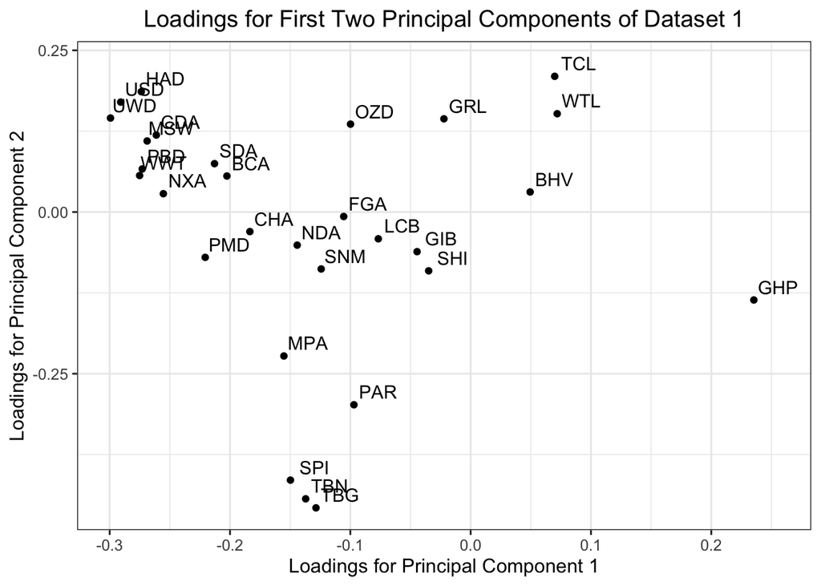

This plot displays the loadings for the first two principal components. The upper left cluster of environmental index indicators shows similar, moderate to strong correlation to the first 2 principal components where they positively correlate with the second principal component and negatively correlate with the first principal component.

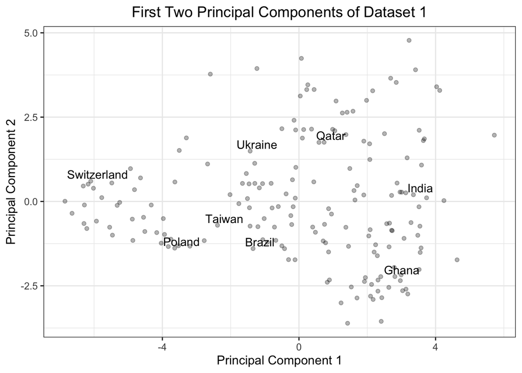

This plot displays 8 countries’ relationships between the two principal components. Switzerland and India are on similar levels compared to the second principal component, but they are on opposite ends in relation to the first principal component. Also countries located in the global north is on the left side of the plot (negative pc1) while countries in the global south are on the right side of the plot (positive pc1).

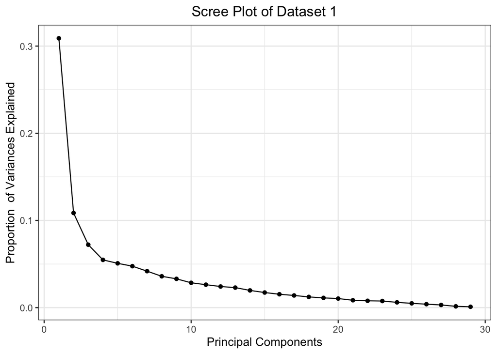

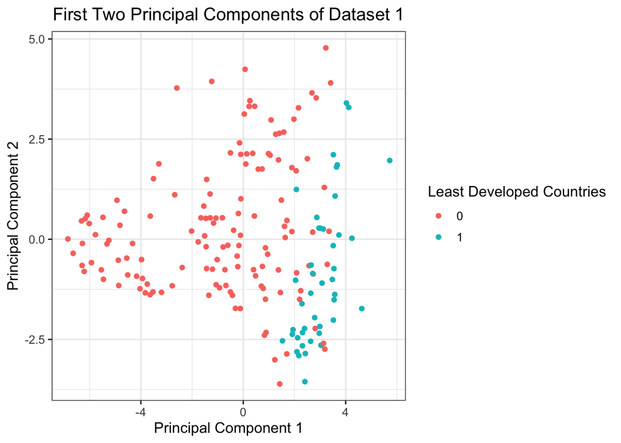

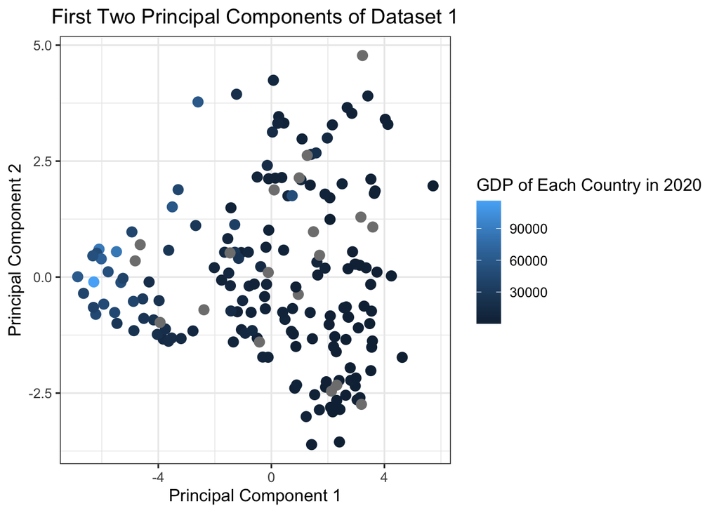

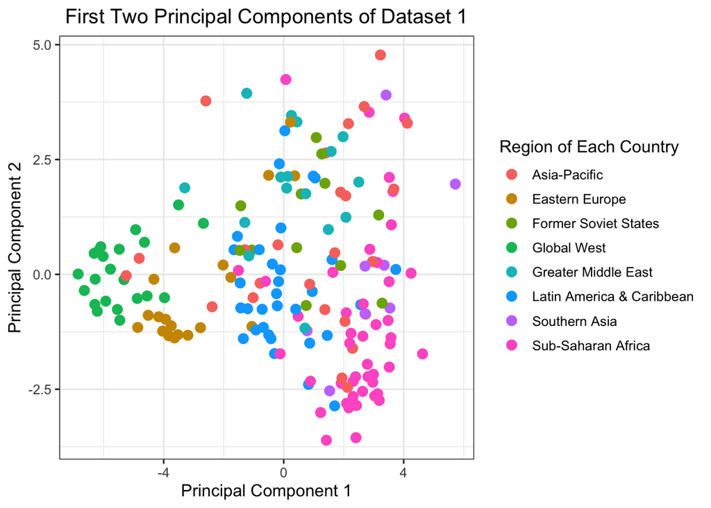

The three plots displayed above aim to investigate variables displayed in the “additional_data.csv” file and their relation to the first principal component. It turns out, from the first plot, the least developed countries have a higher level of principal component 1; from the second plot, countries with the lowest GDPs have a higher level of principal component 1; from the third plot, countries located in the global south have a higher level of principal component 1.

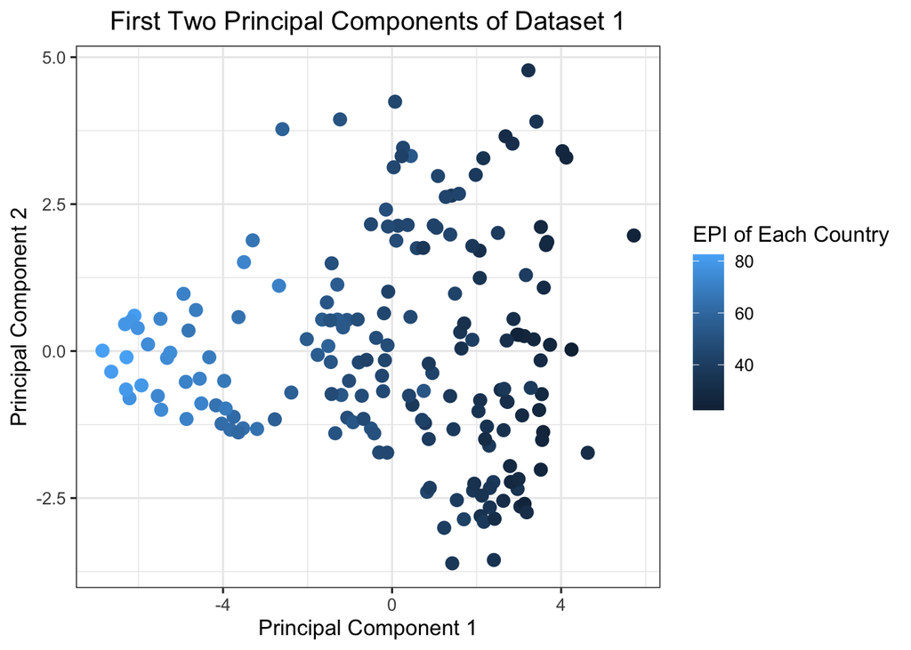

This plot compares the first principle component to the EPI score of each country. Since the first principle component captures the most portion of variances explained in the dataset, I expected it to have some correlation with the EPI score, which was created based on all indicators within this dataset. It turns out, countries with a lower principle component 1 has a higher EPI score, and vice versa.

#### Conclusion

The findings of this project reveal the correlation between economic conditions of a country and its environmental performance. The more developed countries where they typically have higher GDPs and are located in the global north tend to have a higher EPI score, which isn’t a surprise as those countries have the resources they need to develop technologies to reduce pollution and waste. On the other hand, the least developed countries where they typically have lower GDPs and are located in the global south tend to have a lower EPI score, suggesting that wealth disparity is a significant factor in a country’s environmental performance.